# Background:

- In this case, we developed a predictive model and a decision support system that evaluates the risk of Home Equity Line of Credit (HELOC) applications. HELOC is a line of credit that is usually provided by banks. Customers in this data set requested credit lines between $5,000 and $150,000. Our model uses information from applicants' credit reports to predict whether they will repay their HELOC account within 2 years.

## Datasets

- "heloc_dataset": records information on more than 10,000 applicants. For example:Number Trades 90+ Ever; RiskPerformance

## Variables:

- predicted target variable is a binary variable named “RiskPerformance”. A "bad" value means a consumer is at least 90 days overdue or worse within 24 months of opening a credit account. A value of "good" means they have paid and are not more than 90 days overdue.
- The predictor variables are all quantitative or categorical, and come from anonymized credit bureau data.
- there are three special values: -7, -8 and -9, which refer to variables that have different reasons for the value not being available. -9 means no credit history/score information is available. -8 means available or active for account/transaction means inactive or very old. -7 means that conditions are not met (for example, no query, no delinquencies).

## Analysis Tasks

- Clean Data
  - Deal with missing values
- Model Selection
  - Linaer models
  - Tree-based models
  - Parameters tuning
- Decision Support System

## Data cleaning

```python
#Set up

import os
import pandas as pd
import numpy as np
import matplotlib.pyplot as plt
import pickle
from sklearn.model_selection import train_test_split
from sklearn.compose import ColumnTransformer
from sklearn.impute import SimpleImputer
from sklearn.pipeline import FeatureUnion
from sklearn.impute import MissingIndicator
from sklearn.pipeline import Pipeline
from sklearn import tree, linear_model, neighbors
from sklearn.linear_model import LogisticRegression
from sklearn.discriminant_analysis import LinearDiscriminantAnalysis
from sklearn.linear_model import SGDClassifier
from sklearn.linear_model import LogisticRegressionCV
from sklearn.model_selection import cross_validate
from sklearn.model_selection import GridSearchCV
from sklearn.ensemble import RandomForestClassifier
import sklearn.metrics as metrics
import seaborn as sn
from sklearn.ensemble import AdaBoostClassifier

#Load Data
df = pd.read_csv("heloc_dataset_v1.csv")
col_names = list(df.columns)
df.head()
```

|  | RiskPerformance | ExternalRiskEstimate | MSinceOldestTradeOpen | MSinceMostRecentTradeOpen | AverageMInFile | NumSatisfactoryTrades | NumTrades60Ever2DerogPubRec | NumTrades90Ever2DerogPubRec | PercentTradesNeverDelq | MSinceMostRecentDelq | ... | PercentInstallTrades | MSinceMostRecentInqexcl7days | NumInqLast6M | NumInqLast6Mexcl7days | NetFractionRevolvingBurden | NetFractionInstallBurden | NumRevolvingTradesWBalance | NumInstallTradesWBalance | NumBank2NatlTradesWHighUtilization | PercentTradesWBalance |
| --- | --- | --- | --- | --- | --- | --- | --- | --- | --- | --- | --- | --- | --- | --- | --- | --- | --- | --- | --- | --- | --- |
| 0 | Bad | 55 | 144 | 4 | 84 | 20 | 3 | 0 | 83 | 2 | ... | 43 | 0 | 0 | 0 | 33 | -8 | 8 | 1 | 1 | 69 |
| 1 | Bad | 61 | 58 | 15 | 41 | 2 | 4 | 4 | 100 | -7 | ... | 67 | 0 | 0 | 0 | 0 | -8 | 0 | -8 | -8 | 0 |
| 2 | Bad | 67 | 66 | 5 | 24 | 9 | 0 | 0 | 100 | -7 | ... | 44 | 0 | 4 | 4 | 53 | 66 | 4 | 2 | 1 | 86 |
| 3 | Bad | 66 | 169 | 1 | 73 | 28 | 1 | 1 | 93 | 76 | ... | 57 | 0 | 5 | 4 | 72 | 83 | 6 | 4 | 3 | 91 |
| 4 | Bad | 81 | 333 | 27 | 132 | 12 | 0 | 0 | 100 | -7 | ... | 25 | 0 | 1 | 1 | 51 | 89 | 3 | 1 | 0 | 80 |

5 rows × 24 columns

```python
#Variable selection
X = df.copy().drop(["RiskPerformance","MSinceOldestTradeOpen","MSinceMostRecentTradeOpen","AverageMInFile","PercentTradesWBalance"
                   ], axis = 1)
Y = df["RiskPerformance"]
Y = Y.replace({"Bad":1, "Good":0})

df = pd.concat([X, Y], axis=1)
df.head()
```

|  | ExternalRiskEstimate | NumSatisfactoryTrades | NumTrades60Ever2DerogPubRec | NumTrades90Ever2DerogPubRec | PercentTradesNeverDelq | MSinceMostRecentDelq | MaxDelq2PublicRecLast12M | MaxDelqEver | NumTotalTrades | NumTradesOpeninLast12M | PercentInstallTrades | MSinceMostRecentInqexcl7days | NumInqLast6M | NumInqLast6Mexcl7days | NetFractionRevolvingBurden | NetFractionInstallBurden | NumRevolvingTradesWBalance | NumInstallTradesWBalance | NumBank2NatlTradesWHighUtilization | RiskPerformance |
| --- | --- | --- | --- | --- | --- | --- | --- | --- | --- | --- | --- | --- | --- | --- | --- | --- | --- | --- | --- | --- |
| 0 | 55 | 20 | 3 | 0 | 83 | 2 | 3 | 5 | 23 | 1 | 43 | 0 | 0 | 0 | 33 | -8 | 8 | 1 | 1 | 1 |
| 1 | 61 | 2 | 4 | 4 | 100 | -7 | 0 | 8 | 7 | 0 | 67 | 0 | 0 | 0 | 0 | -8 | 0 | -8 | -8 | 1 |
| 2 | 67 | 9 | 0 | 0 | 100 | -7 | 7 | 8 | 9 | 4 | 44 | 0 | 4 | 4 | 53 | 66 | 4 | 2 | 1 | 1 |
| 3 | 66 | 28 | 1 | 1 | 93 | 76 | 6 | 6 | 30 | 3 | 57 | 0 | 5 | 4 | 72 | 83 | 6 | 4 | 3 | 1 |
| 4 | 81 | 12 | 0 | 0 | 100 | -7 | 7 | 8 | 12 | 0 | 25 | 0 | 1 | 1 | 51 | 89 | 3 | 1 | 0 | 1 |

```python
#Explore missing value

#Distribution of -7, -8 and -9
df_count_missing = pd.concat([(df==-7).sum(), (df==-8).sum(), (df==-9).sum()], axis=1)
df_count_missing.columns = [-7,-8,-9]
df_count_missing
```

|  | -7 | -8 | -9 |
| --- | --- | --- | --- |
| ExternalRiskEstimate | 0 | 0 | 598 |
| NumSatisfactoryTrades | 0 | 0 | 588 |
| NumTrades60Ever2DerogPubRec | 0 | 0 | 588 |
| NumTrades90Ever2DerogPubRec | 0 | 0 | 588 |
| PercentTradesNeverDelq | 0 | 0 | 588 |
| MSinceMostRecentDelq | 4664 | 176 | 588 |
| MaxDelq2PublicRecLast12M | 0 | 0 | 588 |
| MaxDelqEver | 0 | 0 | 588 |
| NumTotalTrades | 0 | 0 | 588 |
| NumTradesOpeninLast12M | 0 | 0 | 588 |
| PercentInstallTrades | 0 | 0 | 588 |
| MSinceMostRecentInqexcl7days | 1855 | 476 | 588 |
| NumInqLast6M | 0 | 0 | 588 |
| NumInqLast6Mexcl7days | 0 | 0 | 588 |
| NetFractionRevolvingBurden | 0 | 186 | 588 |
| NetFractionInstallBurden | 0 | 3419 | 588 |
| NumRevolvingTradesWBalance | 0 | 156 | 588 |
| NumInstallTradesWBalance | 0 | 861 | 588 |
| NumBank2NatlTradesWHighUtilization | 0 | 583 | 588 |
| RiskPerformance | 0 | 0 | 0 |

Rows with -9 always don't have all the data on those rows. If we remove rows we will lose data from 598 rows out of 10000, but if we replace the all -9 with the means of those columns,we would have a large proportion of data with the same value in the middle of data in each column, which would influence our prediction accuracy. So, when dealing with -9, we delete all rows with -9 in the "ExternalRiskEstimate" column to improve the reliability and accuracy of our prediction model

```python
#Split into train set and test set
from sklearn.model_selection import train_test_split
X_train, X_test = train_test_split(X, test_size=0.2, random_state=1234)
Y_train, Y_test = train_test_split(Y, test_size=0.2, random_state=1234)

df_train = pd.concat([X_train, Y_train], axis=1)
```

```python
#Remove rows with -9

X_train = X_train[X_train['ExternalRiskEstimate'] != -9]
Y_train = Y_train[df_train['ExternalRiskEstimate'] != -9]

df_test = pd.concat([X_test, Y_test], axis=1)
X_test = X_test[df_test['ExternalRiskEstimate'] != -9]
Y_test = Y_test[df_test['ExternalRiskEstimate'] != -9]
```

```python
#Create Pipeline to replace -7 and -8 with average

do_nothing_imputer = ColumnTransformer([("Imputer -7 to mean", SimpleImputer(missing_values=-7, strategy='mean'), [])], remainder='passthrough')

feature_expansion = FeatureUnion([("do nothing", do_nothing_imputer),
                                  ("add features for -7", MissingIndicator(missing_values=-7, features='missing-only')),
                                  ("add features for -8", MissingIndicator(missing_values=-8, features='missing-only'))])

pipeline= Pipeline([("expand features", feature_expansion),
                 ("replace -7 with -8", SimpleImputer(missing_values=-7, strategy='constant', fill_value=-8)),
                 ("replace -8 with mean", SimpleImputer(missing_values=-8, strategy='mean'))])

arr_X_train_t = pipeline.fit_transform(X_train)

minus_7_indicator_transformer = MissingIndicator(missing_values=-7, features='missing-only').fit(X_train)
minus_8_indicator_transformer = MissingIndicator(missing_values=-8, features='missing-only').fit(X_train)



col_names_minus_7 = X_train.columns.values[minus_7_indicator_transformer.features_].tolist()
col_names_minus_7 = list(map(lambda s:str(s)+'=-7',col_names_minus_7))
col_names_minus_8 = X_train.columns.values[minus_8_indicator_transformer.features_].tolist()
col_names_minus_8 = list(map(lambda s:str(s)+'=-8',col_names_minus_8))
column_names = X_train.columns.values.tolist() + col_names_minus_7 + col_names_minus_8

X_train_t = pd.DataFrame(arr_X_train_t, columns=column_names)

X_test_t = pipeline.transform(X_test)
X_test_t = pd.DataFrame(X_test_t, columns=column_names)
```

## Model Selection

### Linear model

```python
#logistic regression
clf_log_reg = linear_model.LogisticRegression(max_iter=10000).fit(X_train_t, Y_train)
#Cross-validation
cv_results_log_reg = cross_validate(linear_model.LogisticRegression(max_iter=10000), X_train_t, Y_train, cv=5, return_estimator=True)
print('Logistic regresion - CV accuracy score %.3f'%cv_results_log_reg['test_score'].mean())
print('Logistic regresion - test accuracy score: %.3f'%accuracy_score(Y_test, clf_log_reg.predict(X_test_t)))
```

```
Logistic regresion - CV accuracy score 0.737
Logistic regresion - test accuracy score: 0.720
```

```python
# Linear SVM
svc     = SGDClassifier(max_iter=1000, random_state=0).fit(X_train_t, Y_train)
cv_svc = cross_validate(SGDClassifier(max_iter=1000, random_state=0), X_train_t, Y_train, cv=5, return_estimator=True)
print('Svc - CV accuracy score %.3f'%cv_svc['test_score'].mean())
print('Linear SVC test accuracy: %.3f'%svc.score(X_test_t, Y_test))
```

```
Svc - CV accuracy score 0.544
Linear SVC test accuracy: 0.698
```

```python
#LDA
lda     = LinearDiscriminantAnalysis().fit(X_train_t, Y_train)
cv_lda = cross_validate(LinearDiscriminantAnalysis(), X_train_t, Y_train, cv=5, return_estimator=True)
print('Lda - CV accuracy score %.3f'%cv_lda ['test_score'].mean())
print('LDA test accuracy: %.3f'%lda.score(X_test_t, Y_test))
```

```
Lda - CV accuracy score 0.737
LDA test accuracy: 0.720
```

```python
#K-nearest neighbors
clf_knn     = neighbors.KNeighborsClassifier().fit(X_train_t, Y_train)
cv_results_knn = cross_validate(neighbors.KNeighborsClassifier(), X_train_t, Y_train, cv=5, return_estimator=True)
print('KNN - CV accuracy score %.3f'%cv_results_knn['test_score'].mean())
print('KNN - test accuracy score: %.3f'%accuracy_score(Y_test, clf_knn.predict(X_test_t)))
```

```
KNN - CV accuracy score 0.683
KNN - test accuracy score: 0.678
```

After running basic models, we tried to tuning parameters for logistics regression.

```python
#Parameters tuning

exp_lb1, exp_ub1, num_values1 = -2, 2, 30
Cs = np.geomspace(10**exp_lb1, 10**exp_ub1, num_values1)
fico_logistic1 = LogisticRegressionCV(Cs=Cs, cv=5, random_state=0, penalty='l1', solver='liblinear').fit(X_train_t, Y_train)
means1 = fico_logistic1.scores_[1].mean(axis=0)
stds1 = fico_logistic1.scores_[1].std(axis=0)
best1 = accuracy_score(Y_test, fico_logistic1.predict(X_test_t))

exp_lb2, exp_ub2, num_values2 = -2, 2, 30
Cs = np.geomspace(10**exp_lb2, 10**exp_ub2, num_values2)
fico_logistic2 = LogisticRegressionCV(Cs=Cs, cv=5, random_state=0, penalty='l2', solver='liblinear').fit(X_train_t, Y_train)
means2 = fico_logistic2.scores_[1].mean(axis=0)
stds2 = fico_logistic2.scores_[1].std(axis=0)
best2 = accuracy_score(Y_test, fico_logistic2.predict(X_test_t))
```

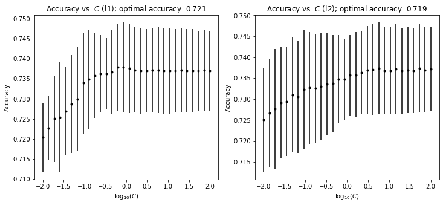

```python
# visualize results (tuning)
fig, axes = plt.subplots(1,2, figsize=(12,5))
axes[0].errorbar(np.linspace(exp_lb1,exp_ub1,num_values2), means1, yerr=stds1, fmt='.k');
axes[0].set_xlabel(r'$\log_{10}(C)$'); axes[0].set_ylabel('Accuracy'); axes[0].set_title(r'Accuracy vs. $C$ (l1); optimal accuracy: %.3f'%best1);
axes[1].errorbar(np.linspace(exp_lb2,exp_ub1,num_values2), means2, yerr=stds2, fmt='.k');
axes[1].set_xlabel(r'$\log_{10}(C)$'); axes[1].set_ylabel('Accuracy'); axes[1].set_title(r'Accuracy vs. $C$ (l2); optimal accuracy: %.3f'%best2);
```

In this process, we found that logistic regression with Penalty l1 would give us the highest accuracy. The optimal accuracy is 0.721. To avoid overfitting, we also add other hyperparameters such as C and solver to improve the performance of the model.

### Tree-based Model

- Decision tree

```python
#Dicision Tree
clf_tree    = tree.DecisionTreeClassifier().fit(X_train_t, Y_train)
cv_results_tree = cross_validate(tree.DecisionTreeClassifier(max_depth=4,min_samples_leaf=20), X_train_t, Y_train, cv=5, return_estimator=True)
print('Classification tree - CV accuracy score %.3f'%cv_results_tree['test_score'].mean())
print('Classification tree - test accuracy score: %.3f'%accuracy_score(Y_test, clf_tree.predict(X_test_t)))
```

```
Classification tree - CV accuracy score 0.716
Classification tree - test accuracy score: 0.633
```

```python
#Decision Tree Parameters tuning
from sklearn.model_selection import GridSearchCV
param_grid = [{'max_depth':[1,2,3,4,5],
               'criterion':["gini", "entropy"],
               'min_samples_split':[2,5,10],
               'min_samples_leaf':[10,20,30]}]
clf_tree = tree.DecisionTreeClassifier()
grid_search = GridSearchCV(clf_tree, param_grid, cv=3, scoring='accuracy')
grid_search.fit(X_train_t,Y_train)
grid_search.best_params_
```

```
{'criterion': 'gini',
 'max_depth': 5,
 'min_samples_leaf': 20,
 'min_samples_split': 5}
```

```python
clf_tree2 = tree.DecisionTreeClassifier(max_depth=5,min_samples_leaf=20).fit(X_train_t, Y_train)
cv_results_tree2 = cross_validate(tree.DecisionTreeClassifier(max_depth=5,min_samples_leaf=20), X_train_t, Y_train, cv=5, return_estimator=True)
print('Classification tree - CV accuracy score %.3f'%cv_results_tree2['test_score'].mean())
print('Classification tree - test accuracy score: %.3f'%accuracy_score(Y_test, clf_tree2.predict(X_test_t)))
```

```
Classification tree - CV accuracy score 0.720
Classification tree - test accuracy score: 0.706
```

- Random forest

```python
rf = RandomForestClassifier(max_depth=1, random_state=0).fit(X_train_t, Y_train)

cv_results_rf= cross_validate(RandomForestClassifier(max_depth=1, random_state=0), X_train_t, Y_train,
                                     cv=5, return_estimator=True)

print('RF - CV accuracy score %.3f'%cv_results_rf['test_score'].mean())
print('RF test accuracy: %.3f'%rf.score(X_test_t, Y_test))
```

```
RF - CV accuracy score 0.701
RF test accuracy: 0.669
```

```python
#Select param for Random forest
from sklearn.model_selection import StratifiedKFold
param_grid = [{'n_estimators':[10,20,50],
               'max_depth':range(1,8),
               'min_samples_leaf':[10,20,100],
               'max_leaf_nodes':[2,4,8,16]}]

grid_search = GridSearchCV(RandomForestClassifier(random_state=10),
                           param_grid,
                           cv=StratifiedKFold(n_splits=5, shuffle=True, random_state=10),
                           scoring='accuracy')

grid_search.fit(X_train_t, Y_train)
```

```
GridSearchCV(cv=StratifiedKFold(n_splits=5, random_state=10, shuffle=True),
             estimator=RandomForestClassifier(random_state=10),
             param_grid=[{'max_depth': range(1, 8),
                          'max_leaf_nodes': [2, 4, 8, 16],
                          'min_samples_leaf': [10, 20, 100],
                          'n_estimators': [10, 20, 50]}],
             scoring='accuracy')
```

```python
grid_search.best_params_
```

```
{'max_depth': 7,
 'max_leaf_nodes': 16,
 'min_samples_leaf': 10,
 'n_estimators': 20}
```

```python
best_RF_model = grid_search.best_estimator_
cv_results_rf_opt= cross_validate(best_RF_model, X_train_t, Y_train,
                                     cv=5, return_estimator=True)

print('RF_opt - CV accuracy score %.3f'%cv_results_rf_opt['test_score'].mean())
print('RF_opt test accuracy: %.3f'%best_RF_model.score(X_test_t, Y_test))
```

```
RF_opt - CV accuracy score 0.728
RF_opt test accuracy: 0.703
```

```
prediction accuracy is 0.702661207778915
```

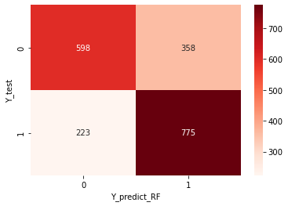

```python
#Visualize
acc=metrics.accuracy_score(y_true=Y_test,y_pred=best_RF_model.predict(X_test_t))
print('prediction accuracy is',acc)
confusion=metrics.confusion_matrix(y_true= Y_test,y_pred=best_RF_model.predict(X_test_t))
# print(confusion)
sn.heatmap(confusion, annot=True, cmap='Reds', fmt='d')
plt.xlabel("Y_predict_RF")
plt.ylabel("Y_test")
```

- Boosting

```python
#boosting model with 0.01 learning rate
clf_boosting_01 = AdaBoostClassifier(n_estimators = 60, random_state=0, learning_rate=0.01).fit(X_train_t, Y_train)
cv_results_boosting_01= cross_validate(AdaBoostClassifier(n_estimators = 60, random_state=0, learning_rate=0.01)
                                  , X_train_t, Y_train,
                                     cv=5, return_estimator=True)

print('clf_boosting_01 - CV accuracy score %.3f'%cv_results_boosting_01['test_score'].mean())
print('clf_boosting_01 test accuracy: %.3f'%clf_boosting_01.score(X_test_t, Y_test))
```

```
clf_boosting_01 - CV accuracy score 0.712
clf_boosting_01 test accuracy: 0.690
```

```python
#boosting model with 1 learning rate
clf_boosting_1 = AdaBoostClassifier(n_estimators = 60, random_state=0, learning_rate=1).fit(X_train_t, Y_train)
cv_results_boosting_1= cross_validate(AdaBoostClassifier(n_estimators = 60, random_state=0, learning_rate=1)
                                  , X_train_t, Y_train,
                                     cv=5, return_estimator=True)

print('clf_boosting_1 - CV accuracy score %.3f'%cv_results_boosting_1['test_score'].mean())
print('clf_boosting_1 test accuracy: %.3f'%clf_boosting_1.score(X_test_t, Y_test))
```

```
clf_boosting_1 - CV accuracy score 0.732
clf_boosting_1 test accuracy: 0.718
```

```python
#boosting model with 1 learning rate
cv_results_boost2 = []
test_accuracy_boost2 = []
for i in range(10,391,10):
    boost2 = AdaBoostClassifier(n_estimators = i, random_state=0, learning_rate=1).fit(X_train_t, Y_train)
    cv_results= cross_validate(AdaBoostClassifier(n_estimators = i, random_state=0, learning_rate=1)
                                  , X_train_t, Y_train,
                                     cv=5, return_estimator=True)
    cv_results_boost2.append(cv_results['test_score'].mean())
    test_boost2_temp = boost2.score(X_test_t, Y_test)
    test_accuracy_boost2.append(test_boost2_temp)


cv_results_boost2 = pd.Series(cv_results_boost2)
test_accuracy_boost2 = pd.Series(test_accuracy_boost2)

boosting_accuracy_learning_rate_1 = pd.concat([cv_results_boost2,test_accuracy_boost2], axis = 1).rename(columns = {0:'Cross Validation accuracy', 1:"Test accuracy"})
boosting_accuracy_learning_rate_1.index.names = ['n_estimators']
boosting_accuracy_learning_rate_1.index = range(10,391,10)
```

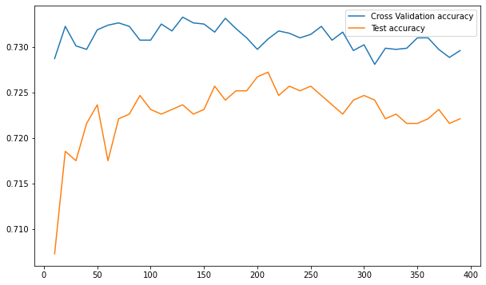

```python
boosting_accuracy_learning_rate_1[["Cross Validation accuracy","Test accuracy"]].plot(figsize=(10,6))
```

```python
#Find the most accurate model
boosting_accuracy_learning_rate_1[boosting_accuracy_learning_rate_1["Test accuracy"] ==
                                  max(boosting_accuracy_learning_rate_1["Test accuracy"])]
```

|  | Cross Validation accuracy | Test accuracy |
| --- | --- | --- |
| 210 | 0.730872 | 0.727226 |

```python
clf_boosting_opt = AdaBoostClassifier(n_estimators = 210, random_state=0, learning_rate=1).fit(X_train_t, Y_train)
cv_results_boosting= cross_validate(AdaBoostClassifier(n_estimators = 210, random_state=0, learning_rate=1)
                                  , X_train_t, Y_train,
                                     cv=5, return_estimator=True)

print('clf_boosting_1 - CV accuracy score %.3f'%cv_results_boosting['test_score'].mean())
print('clf_boosting_1 test accuracy: %.3f'%clf_boosting_opt.score(X_test_t, Y_test))
```

```
clf_boosting_1 - CV accuracy score 0.731
clf_boosting_1 test accuracy: 0.727
```

```
prediction accuracy is 0.7272262026612077
```

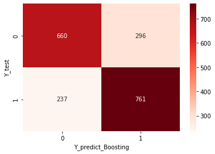

```python
#Visualize
acc=metrics.accuracy_score(y_true=Y_test,y_pred=clf_boosting_opt.predict(X_test_t))
print('prediction accuracy is',acc)
confusion=metrics.confusion_matrix(y_true= Y_test,y_pred=clf_boosting_opt.predict(X_test_t))
# print(confusion)
sn.heatmap(confusion, annot=True, cmap='Reds', fmt='d')
plt.xlabel("Y_predict_Boosting")
plt.ylabel("Y_test")
```

- Bagging

```python
#Bagging Classifier
from sklearn.ensemble import BaggingClassifier
base_clf = tree.DecisionTreeClassifier(max_depth=5,min_samples_leaf=20)

results = []

for n in range(1,60,1):
    clf = BaggingClassifier(n_estimators=n, base_estimator=base_clf,random_state=0)
    clf = clf.fit(X_train_t,Y_train)

    cv_results= cross_validate(BaggingClassifier(n_estimators=n, base_estimator=base_clf,random_state=0)
                                  , X_train_t, Y_train,
                                     cv=5, return_estimator=True)
    cv_results = cv_results['test_score'].mean()
    test = clf.score(X_test_t, Y_test)

    results.append([n,cv_results ,test])
bag_accuracy = pd.DataFrame(data=results,columns=['n_restimators','Cross Validation Accuracy',"Test Accuracy"])
```

```python
bag_accuracy[bag_accuracy["Test Accuracy"] == max(bag_accuracy["Test Accuracy"])]
```

|  | n_restimators | Cross Validation Accuracy | Test Accuracy |
| --- | --- | --- | --- |
| 48 | 49 | 0.732263 | 0.71392 |
| 49 | 50 | 0.730998 | 0.71392 |

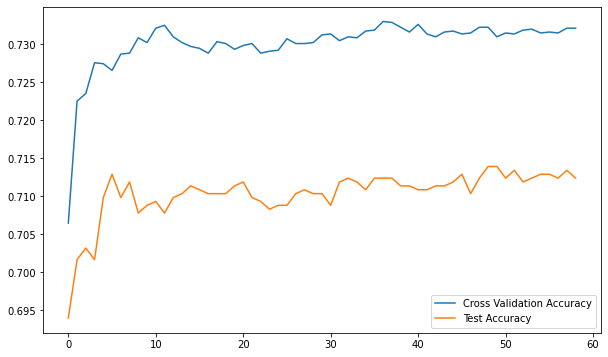

```python
bag_accuracy[["Cross Validation Accuracy","Test Accuracy"]].plot(figsize=(10,6))
```

So after tuning parameters and comparing the accuracy, we decided to put the model with the highest accuracy score into our interface, which is the boosting model with the best parameter combination we found (n_estimators = 210, random_state=0, learning_rate=1). Each of the boosting models tries to make up for the weaknesses of its predecessor. In each iteration, the weak rules from each individual classifier are combined into a strong prediction rule. Since our applicant data set is relatively large, this algorithm of boosting is very beneficial to our prediction of the risk of HELOC applications.

## Decision Support System

- Create website apps using Streamlit

Therefore, with the selected model, we created a decision support system to help bank or credit card companies to decide on accepting or rejecting applications. The system is an interactive interface where users can input the information about applications, and prediction outcomes would be shown.

In terms of users, we expect that users should be someone who is familiar with terms used in banks, such as “delinquency” , “Installment Trades” etc. In this way, users would be able to fill out all information needed. Generally, no other technical skills would be required for using this system.

In terms of input information, a total of 28 variables are required to the predicted model. Users need to fill in 19 blanks, the first 19 variables, and the rest, which are relative to -7 and -8, would be zero by default. To deal with the special value -8 and -7, we would ask the users about whether the applicant has valid trades/inquiries or delinquencies before users enter certain blanks, if not, the system would automatically replace the value of that blank to the means of that column and replace 0 with 1 in corresponding column.

The following is a graph of the interface. After all the inputs were filled, the estimated outcome would automatically be shown. If the estimated outcome shows that the applicant has bad risk performance, you can see “You should reject the application! Estimated outcome indicates that the applicant was 90 days past due or worse at least once over a period of 24 months from when the credit account was opened” on the screen, or you would see “You should accept the application! Estimated outcome indicates that the applicant made their payments without ever being more than 90 days overdue.”

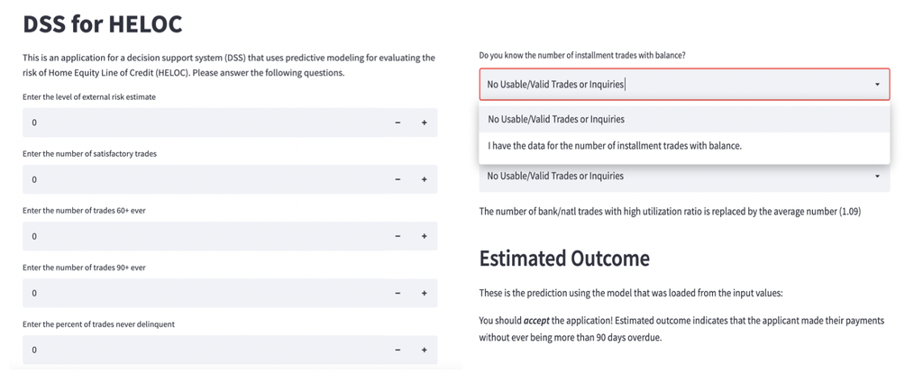

With this system, banks and credit card companies can easily and efficiently get accurate risk predictions of credit card applicants by typing the answers to a series of questions. We sincerely hope that this model can be put into practical work. After monitoring the performance of the model in working use, we will continue to optimize this model to further support bank-related work.